# Sallust (and other historians)

## Greek

- L. Cincius Alimentus
  - Praetor in Sicily in 210/9
  - Captured in the Hannibalic war
  - Started with the regal period, and went down to the Punic Wars *in Greek*
- A. Postumius Albinus
  - Praetor in 155, held other offices, including several in Greece
  - Rome from its origins *in Greek*
- C. Acilius
  - Served as a Greek interpreter in Senate in 155
  - Rome from its origins to at least 184 *in Greek*

## Latin

- L. Cassius Hemina
  - Mid-2nd c.
  - From Troy and Italy up to at least 146 *in Latin*
- L. Calpurnius Piso Frugi
  - 149 Tribune, 133 Consul in Sicily, 120 Censor
  - *Annales* in 7 books up to his own time
  - Decline of the Republic began in 154
- C. Licinius Macer
  - 73 Tribune, 66 Praetor, 63 Convicted for extortion and suicide
  - History in at least 16 books from origins, Pyrrhus in book 2

## C. Sallustius Crispus

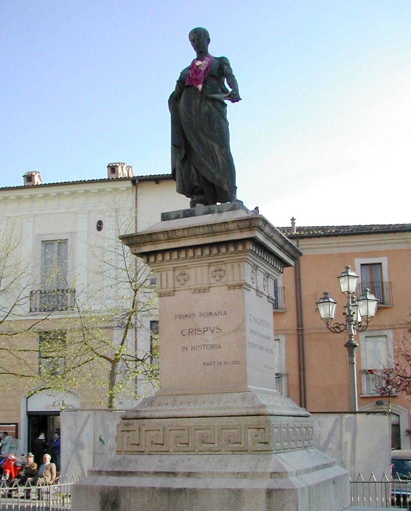

Modern statue of Sallust

## Life

- Lived 86 – c. 35 BC

## Career

*Popularis* politician and *novus homo* from a provincial plebeian family of Amiternum

- Tribune of the Plebs in 52 BC, when followers of Milo killed Clodius in a street brawl; supported the prosecution of Milo
- Censor Appius Claudius Pulcher removed him from the Senate in 50 BC, on the grounds of gross immorality
- 49 re-instated probably due to Caesar
- 49 Moved to Illyricum and probably commanded at least one legion
- 48 Perhaps moved back to Rome and made quaestor to enter the senate
- 46 Praetor, accompanied Caesar in his African campaign
- Given governorship of Africa Nova for which he was prosecuted
- Bought gardens in Rome & retired

## Works

- *Catiline’s War* (conspiracy in 63 BC of L. Sergius Catilina)
  - Not annalistic, but monogram on one topic
  - Strong moralizing
  - Fall of Rome begins after the defeat of Carthage and the lack of an external enemy
- *The Jugurthine War* (war against the Numidians 111 to 105 BC)
  - Also monograph
- *Histories*
  - fragmentary annals covering 78 to ???

Very influenced by the Greek historian Thucydides in his style and in turn influenced Tacitus